# Baseballr EDA

Charlie Braverman, Beili Chou, Andrew Hack

2025-02-27

## Conventions

with_underscores

Variables: nouns

Functions: verbs

Automated ball-strike challenge system -> ABS

Major League Baseball -> MLB

## Packages

Uncommon pkgs: baseballr Petti and Gilani (n.d.)

baseballr is a package written for R focused on baseball analysis. It includes functions for scraping various data from websites, such as FanGraphs.com, Baseball-Reference.com, and baseballsavant.mlb.com. It also includes functions for calculating metrics, such as wOBA, FIP, and team-level consistency over custom time frames.

You can read more about some of the functions and how to use them at its official site, http://billpetti.github.io/baseballr/index.html.

```r
library(tidyverse)
library(baseballr)
```

## Data

Statcast provides pitch-by-pitch data for every game played in MLB. Our approach will be to pull pitch data and join with another data set that holds: batter_id, batter_name, and batter_height. This full data set will allow for us to sort by batter produce the new rulebook strike zone for each.

Further documentation on variable names and their meanings can be found here: https://baseballsavant.mlb.com/csv-docs

Biofile data is obtained from https://www.retrosheet.org/biofile.htm, specifically the biofile0 since it contains heights in inches.

One assumption that must be made is that batting stance will not affect the strike zone. This is a simplification that will be made for the sake of this analysis. In the future, maybe Statcast data will be used to record batting stance height, and this assumption can be revisited.

This chunk should take about 2-3 minutes to run.

Taking a look at pitch location data, which is broken down into x (horizontal) and z (vertical) coordinates:

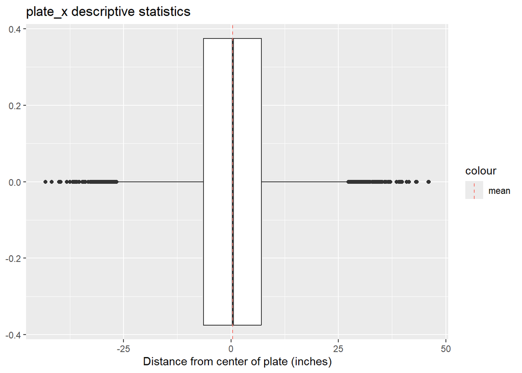

```r
# boxplots for plate_x and plate_z
plate_x_bplot <- ggplot(full_pitch_df, aes(x = plate_x)) +
  geom_boxplot() +
  labs(title = "plate_x descriptive statistics", x = "Distance from center of plate (inches)")

plate_z_bplot <- ggplot(full_pitch_df, aes(y = plate_z)) +
  geom_boxplot() +
  labs(title = "plate_z descriptive statistics", y = "Distance from ground (inches)")

plate_x_bplot + geom_vline(aes(xintercept = mean(plate_x), color = "mean"), linetype = "dashed")
```

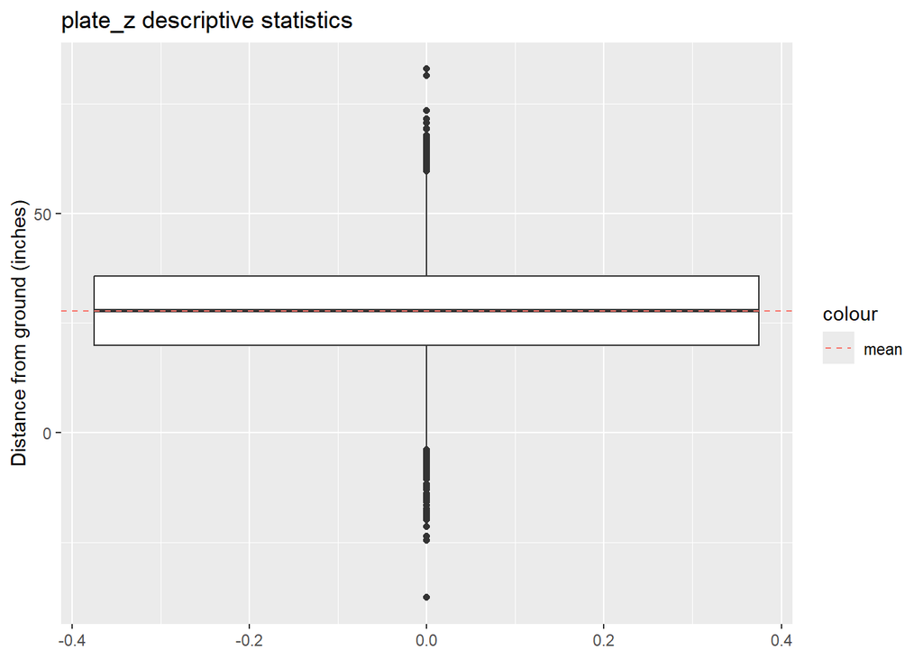

```r
plate_z_bplot + geom_hline(aes(yintercept = mean(plate_z), color = "mean"), linetype = "dashed")
```

```r
# summary statistics for plate_x and plate_z
summary(full_pitch_df$plate_x)
```

```
##     Min.  1st Qu.   Median     Mean  3rd Qu.     Max.
## -43.2000  -6.3600   0.3600   0.3557   7.0800  46.0800
```

```r
summary(full_pitch_df$plate_z)
```

```
##    Min. 1st Qu.  Median    Mean 3rd Qu.    Max.
##  -37.56   19.92   27.84   27.73   35.76   82.92
```

And taking a look at how much the strike zone varies across different batters:

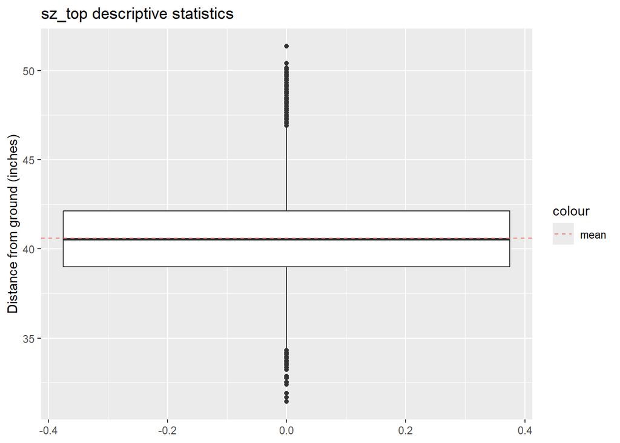

```r
# boxplots for sz_top and sz_bot
sz_top_bplot <- ggplot(full_pitch_df, aes(y = sz_top)) +
  geom_boxplot() +
  labs(title = "sz_top descriptive statistics", y = "Distance from ground (inches)")

sz_bot_bplot <- ggplot(full_pitch_df, aes(y = sz_bot)) +
  geom_boxplot() +
  labs(title = "sz_bot descriptive statistics", y = "Distance from ground (inches)")

sz_top_bplot + geom_hline(aes(yintercept = mean(sz_top), color = "mean"), linetype = "dashed")
```

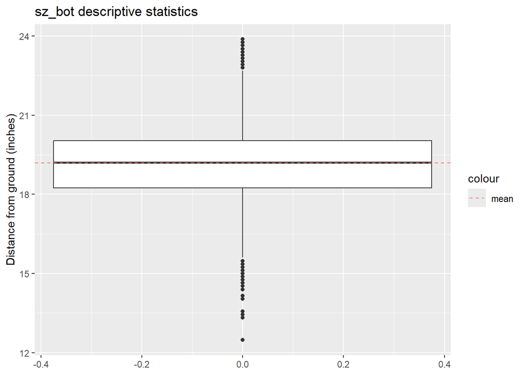

```r
sz_bot_bplot + geom_hline(aes(yintercept = mean(sz_bot), color = "mean"), linetype = "dashed")
```

```r
# summary statistics for sz_top and sz_bot
summary(full_pitch_df$sz_top)
```

```
##    Min. 1st Qu.  Median    Mean 3rd Qu.    Max.
##   31.44   39.00   40.56   40.62   42.12   51.36
```

```r
summary(full_pitch_df$sz_bot)
```

```
##    Min. 1st Qu.  Median    Mean 3rd Qu.    Max.
##   12.48   18.24   19.20   19.20   20.04   23.88
```

## EDA

Some initial thoughts:

How does player height currently relate to strike zone bot/top?

#### Exploring strikezone sizes:

```r
# group by batter height and calculate average strike zone top and bottom
full_pitch_df %>% group_by(batter_height) %>% summarise(avg_abs_sz_top = mean(abs_sz_top), avg_abs_sz_bot = mean(abs_sz_bot), avg_sz_top = mean(sz_top), avg_sz_bot = mean(sz_bot))
```

```
## # A tibble: 14 × 5
##    batter_height avg_abs_sz_top avg_abs_sz_bot avg_sz_top avg_sz_bot
##            <dbl>          <dbl>          <dbl>      <dbl>      <dbl>
##  1            66           35.3           17.8       36.3       17.0
##  2            67           35.8           18.1       38.8       18.0
##  3            68           36.4           18.4       38.8       18.3
##  4            69           36.9           18.6       39.0       18.2
##  5            70           37.4           18.9       38.7       17.9
##  6            71           38.0           19.2       39.9       18.8
##  7            72           38.5           19.4       39.8       18.8
##  8            73           39.1           19.7       40.3       19.2
##  9            74           39.6           20.0       41.2       19.5
## 10            75           40.1           20.2       42.0       20.0
## 11            76           40.7           20.5       42.2       20.0
## 12            77           41.2           20.8       43.0       20.8
## 13            78           41.7           21.1       45.1       21.5
## 14            79           42.3           21.3       47.6       21.8
```

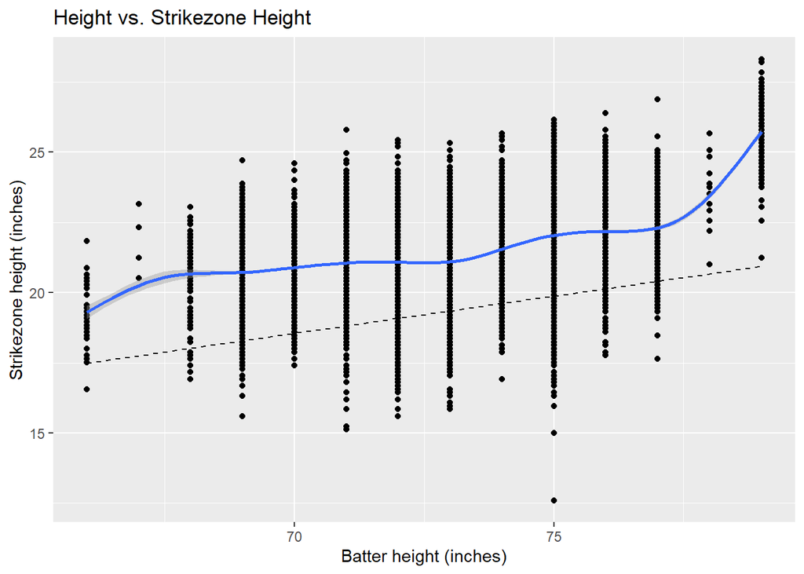

```r
# graph of sz height vs batter_height, with the new strike zone height as a reference line
sz_height_vs_height <- ggplot(full_pitch_df, aes(x = batter_height, y = sz_height)) +
  geom_point() + geom_smooth(method = "gam") + geom_line(aes(x = batter_height, y = abs_sz_height), linetype = "dashed") +
  labs(title = "Height vs. Strikezone Height", x = "Batter height (inches)", y = "Strikezone height (inches)")

sz_height_vs_height
```

#### Calculating strikezone differences for 2024:

```
Start

  Mutate and create % strikezone diff

    Calculate average height x width for recorded strikezone and compare % area difference to ABS strikezone.

  Mutate and create batting average on balls in zone (BABIZ) for old and new zones

    Filter for pitches located in each zone, respectively, and calculate average

  Repeat for interesting stats

    wOBA/BABIPIZ/...

  Compare players who benefit vs suffer

    Group_by, sort

End
```

#### Long-term: model player performances for 2024 if strikezone was ABS size:

```
Start

  Create distance from  strikezone metric

    ball_loc-nearest strikezone edge

  Train model on distance from strikezone edge, count, more etc

    Start with metrics like BA, can model other stats as well, ~ distance_from_zone, count, pitch velo, pitch break, etc

  Mutate predicted field to be NA for each pitch that is on the line between old and new zone

    filter for pitch location in ABS-Zone distance away from zone, make NA

  Predict outcome for those limbo-state pitches with new strike zone

  Make sure model is trained so if a batter would swing at a pitch on the edge of old zone, their habits stay true (and same if not swinging)

  Calculate difference in WAR, other key metrics for players. Who performed better? Worse?

End
```

Petti, Bill, and Saiem Gilani. n.d. “Baseballr: Acquiring and Analyzing Baseball Data.” https://github.com/BillPetti/baseballr.